# XGBoost - Multiclasificacion

Alejandro Bedoya - Sebastián Agudelo - Mateo Espinal - Juan Fernando Patiño - Estefanía Echeverry

Marzo 2021

# Carga de paquetes

```r
library("xgboost")
library("caret")
library("dplyr")
library("e1071")
library("Ckmeans.1d.dp")
```

# Lectura de las bases de datos

```r
set.seed(123)
setwd("C:/Users/123/Desktop/TAE/Actividades/TRABAJO 1")
train <- read.csv("train.csv", header = TRUE)
test <- read.csv("test.csv", header = TRUE)
train <- train[,-c(1)]
test <- test[,-c(1)]
summary(train$Hijos) #El algoritmo precisa que se empiece en 0
```

```
##    Min. 1st Qu.  Median    Mean 3rd Qu.    Max.
##   0.000   0.000   1.000   1.119   2.000  11.000
```

# Creación de matrices xgb

Primero la partición de respuesta y covariables para cada base en matrices y vectores.

```r
train_label  <- train[,"Hijos"]
test_label <- test[,"Hijos"]
train_covariables <- as.matrix(train[,-1])
test_covariables <- as.matrix(test[,-1])
```

Ahora la creación de las matrices de entrenamiento y prueba

```r
train_matrix <- xgb.DMatrix(data = train_covariables, label = train_label)
test_matrix <- xgb.DMatrix(data = test_covariables, label = test_label)
```

# Validación cruzada en k-folds para estimar el error

Entrenamiento del modelo final. Los parámetros pueden ser optimizados vía optimizador Bayesiano.

```r
numero_de_clases <- length(unique(train$Hijos))
parametros_xgb <- list("objective"="multi:softprob",
                       "eval_metric"="mlogloss",
                       "num_class"=numero_de_clases)
nrondas <- 50  #Número máximo de rondas a ejecutar en el boosteo
nfolds_cv <- 5

# Ajusta cv.nfold * cv.nround XGB models and save OOF predictions
modelo_cv <- xgb.cv(params = parametros_xgb,
                   data = train_matrix,
                   nrounds = nrondas,
                   nfold = nfolds_cv,
                   verbose = FALSE,
                   prediction = TRUE)
```

# Error de las predicciones usando una muestra Out of Fold (OOF)

La muestra out of fold es una sub-muestra que se hace en el procedimiento y que no se incluye para el entrenamiento funcionando, a pequeña escala, como otro test-set que da una idea de cómo se está comportando el modelo antes de que lo tanteemos en el test set definitivo.

```r
prediccion_OOF <- data.frame(modelo_cv$pred) %>%
  mutate(max_prob = max.col(., ties.method = "last"),
         label = train_label+1)
head(prediccion_OOF)
```

```
##           X1           X2           X3           X4           X5           X6
## 1 0.01468720 1.378140e-01 2.733503e-01 4.238118e-01 1.167475e-01 2.076318e-02
## 2 0.99856633 1.374915e-03 1.839038e-05 7.628879e-06 4.868315e-06 4.080988e-06
## 3 0.05511593 1.698701e-01 7.746404e-01 6.539881e-05 4.635746e-05 3.886031e-05
## 4 0.99993849 5.063953e-05 3.579681e-06 1.321562e-06 9.015435e-07 7.557416e-07
## 5 0.28904930 7.103829e-01 1.872463e-04 6.515775e-05 4.682224e-05 3.924993e-05
## 6 0.01396583 5.979528e-02 3.403981e-01 5.827776e-01 2.642839e-03 5.924881e-05
##             X7           X8           X9          X10          X11          X12
## 1 7.778324e-03 1.419240e-03 3.387682e-03 8.090545e-05 7.954273e-05 8.027491e-05
## 2 3.967431e-06 4.399805e-06 3.899780e-06 3.862081e-06 3.819380e-06 3.821938e-06
## 3 3.777903e-05 3.846197e-05 3.713484e-05 3.677585e-05 3.636921e-05 3.639361e-05
## 4 7.347119e-07 7.479935e-07 7.221840e-07 7.152025e-07 7.072950e-07 7.077687e-07
## 5 3.815777e-05 4.294893e-05 3.750712e-05 3.714454e-05 3.673385e-05 3.675846e-05
## 6 5.757216e-05 7.975118e-05 5.657218e-05 5.633690e-05 5.545528e-05 5.538240e-05
##   max_prob label
## 1        4     6
## 2        1     1
## 3        3     1
## 4        1     1
## 5        2     2
## 6        4     4
```

# Matriz de confusión para la predicción con OOF

```r
confusionMatrix(factor(prediccion_OOF$max_prob),
                factor(prediccion_OOF$label),
                mode = "everything")
```

```
## Confusion Matrix and Statistics
##
##           Reference
## Prediction     1     2     3     4     5     6     7     8     9    10    11
##         1  21889   575    79    13     5     0     1     0     0     0     0
##         2   3059 14754  1414   383    69    14     0     0     0     0     0
##         3    526  2293 10293   598   162    47     9     3     1     0     0
##         4     96   490  1269  3764   202    62    27     2     2     0     1
##         5     13   103   268   440  1150    95    21     3     1     0     0
##         6     10    14    60    86   135   300    30    13     2     0     0
##         7      2     5    19    24    31    50   102    10     5     1     1
##         8      1     2     3     6     3    15    18    29     7     2     0
##         9      1     0     1     0     3     4     4     4     8     0     0
##         10     0     1     1     0     0     0     0     0     0     0     0
##         11     0     0     0     2     0     0     0     0     0     0     0
##         12     0     0     0     0     0     0     0     0     0     0     0
##           Reference
## Prediction    12
##         1      0
##         2      0
##         3      0
##         4      0
##         5      2
##         6      0
##         7      0
##         8      0
##         9      0
##         10     0
##         11     0
##         12     0
##
## Overall Statistics
##
##                Accuracy : 0.8018
##                  95% CI : (0.7987, 0.8049)
##     No Information Rate : 0.3925
##     P-Value [Acc > NIR] : < 2.2e-16
##
##                   Kappa : 0.7276
##
```

[output cut: 13 more lines]

```
## Detection Rate         0.3357   0.2262   0.1578  0.05772  0.01763 0.004600
## Detection Prevalence   0.3460   0.3020   0.2136  0.09070  0.03214 0.009967
## Balanced Accuracy      0.9191   0.8519   0.8487  0.83607  0.81925 0.752829
##                      Class: 7  Class: 8  Class: 9 Class: 10 Class: 11 Class: 12
## Sensitivity          0.481132 0.4531250 0.3076923 0.000e+00 0.000e+00 0.000e+00
## Specificity          0.997723 0.9991251 0.9997392 1.000e+00 1.000e+00 1.000e+00
## Pos Pred Value       0.408000 0.3372093 0.3200000 0.000e+00 0.000e+00       NaN
## Neg Pred Value       0.998307 0.9994626 0.9997239 1.000e+00 1.000e+00 1.000e+00
## Precision            0.408000 0.3372093 0.3200000 0.000e+00 0.000e+00        NA
## Recall               0.481132 0.4531250 0.3076923 0.000e+00 0.000e+00 0.000e+00
## F1                   0.441558 0.3866667 0.3137255       NaN       NaN        NA
## Prevalence           0.003251 0.0009814 0.0003987 4.600e-05 3.067e-05 3.067e-05
## Detection Rate       0.001564 0.0004447 0.0001227 0.000e+00 0.000e+00 0.000e+00
## Detection Prevalence 0.003834 0.0013188 0.0003834 3.067e-05 3.067e-05 0.000e+00
## Balanced Accuracy    0.739428 0.7261250 0.6537158 5.000e-01 5.000e-01 5.000e-01
```

Obsérven que hay buenos valores para los apartados de sensitivity, specificity y en general para precisión, sobre todo al predecir números de hijos no muy grandes. Para los valores más extremos se observa un decaimiento notorio en la precisión. Con esto en mente y viendo el aparente buen desempeño al usar los datos OOF, veamos qué tal se da el desempeño en nuestra base de test

# Entrenamiento del modelo y evaluación del desempeño en datos de prueba

Primero se entrena el modelo con los parámetros predefinidos arriba

```r
parametros_xgb <- list("objective"="multi:softprob",
                       "eval_metric"="mlogloss",
                       "num_class"=numero_de_clases,
                       eta = 0.3,
                       early_stoppin_rounds = 200,
                       nfold =10, nrounds = 1000,
                       max_depth = 6)   #Se puede hacer hyperparameter tunning
modelo_xg <- xgb.train(params = parametros_xgb,
                       data = train_matrix,
                       nrounds = 1000)
```

```
## [20:28:10] WARNING: amalgamation/../src/learner.cc:541:
## Parameters: { early_stoppin_rounds, nfold, nrounds } might not be used.
##
##   This may not be accurate due to some parameters are only used in language bindings but
##   passed down to XGBoost core.  Or some parameters are not used but slip through this
##   verification. Please open an issue if you find above cases.
```

Ahora se hace la predicción para el conjunto de prueba

```r
# Predict para el test set
test_pred <- predict(modelo_xg, newdata = test_matrix)
test_prediction <- matrix(test_pred, nrow = numero_de_clases,
                          ncol=length(test_pred)/numero_de_clases) %>%
  t() %>%
  data.frame() %>%
  mutate(label = test_label+1,
         max_prob = max.col(., "last"))
```

```r
# Matriz de confusión para el test set

confusionMatrix(factor(test_prediction$max_prob),
                factor(test_prediction$label),
                mode = "everything")
```

```
## Confusion Matrix and Statistics
##
##           Reference
## Prediction    1    2    3    4    5    6    7    8    9   10   11
##         1  9533  545   67    9    3    0    0    0    0    0    0
##         2  1177 5979  680  165   40    7    1    1    0    0    0
##         3   259 1019 4389  417  104   12    6    3    0    0    0
##         4    37  191  517 1518  147   46   12    2    3    1    0
##         5    13   22   74  136  401   51    7    2    2    0    0
##         6     1    9   15   34   33  122   16    5    0    0    1
##         7     1    0    2   13   15   14   27    4    0    0    0
##         8     0    0    1    5    2    1    3   14    0    1    0
##         9     0    0    0    1    1    1    2    0    5    0    0
##         10    0    0    0    0    0    0    0    0    0    0    0
##         11    0    0    0    0    0    0    0    0    0    0    0
##
## Overall Statistics
##
##                Accuracy : 0.7868
##                  95% CI : (0.7819, 0.7916)
##     No Information Rate : 0.3944
##     P-Value [Acc > NIR] : < 2.2e-16
##
##                   Kappa : 0.7051
##
##  Mcnemar's Test P-Value : NA
##
## Statistics by Class:
##
##                      Class: 1 Class: 2 Class: 3 Class: 4 Class: 5 Class: 6
## Sensitivity            0.8650   0.7700   0.7640  0.66057  0.53753 0.480315
## Specificity            0.9631   0.8974   0.9180  0.96273  0.98871 0.995883
## Pos Pred Value         0.9386   0.7427   0.7069  0.61358  0.56638 0.516949
## Neg Pred Value         0.9164   0.9102   0.9376  0.96938  0.98733 0.995237
## Precision              0.9386   0.7427   0.7069  0.61358  0.56638 0.516949
## Recall                 0.8650   0.7700   0.7640  0.66057  0.53753 0.480315
## F1                     0.9003   0.7561   0.7343  0.63621  0.55158 0.497959
## Prevalence             0.3944   0.2778   0.2056  0.08223  0.02669 0.009089
## Detection Rate         0.3411   0.2139   0.1570  0.05432  0.01435 0.004365
## Detection Prevalence   0.3634   0.2880   0.2222  0.08852  0.02533 0.008445
## Balanced Accuracy      0.9141   0.8337   0.8410  0.81165  0.76312 0.738099
##                       Class: 7  Class: 8  Class: 9 Class: 10 Class: 11
## Sensitivity          0.3648649 0.4516129 0.5000000 0.000e+00 0.000e+00
## Specificity          0.9982420 0.9995343 0.9998210 1.000e+00 1.000e+00
## Pos Pred Value       0.3552632 0.5185185 0.5000000       NaN       NaN
## Neg Pred Value       0.9983137 0.9993911 0.9998210 9.999e-01 1.000e+00
## Precision            0.3552632 0.5185185 0.5000000        NA        NA
## Recall               0.3648649 0.4516129 0.5000000 0.000e+00 0.000e+00
## F1                   0.3600000 0.4827586 0.5000000        NA        NA
## Prevalence           0.0026479 0.0011092 0.0003578 7.156e-05 3.578e-05
## Detection Rate       0.0009661 0.0005009 0.0001789 0.000e+00 0.000e+00
## Detection Prevalence 0.0027194 0.0009661 0.0003578 0.000e+00 0.000e+00
## Balanced Accuracy    0.6815534 0.7255736 0.7499105 5.000e-01 5.000e-01
```

# Importancia de las variables

```r
# Nombres de las variables
nombres <-  colnames(train[,-1])
# Muestra la matriz de importancia de las variables
matriz_de_importancia = xgb.importance(feature_names = nombres, model = modelo_xg)
head(matriz_de_importancia)
```

```
##                Feature       Gain       Cover  Frequency
## 1: CANT_PERSONAS_HOGAR 0.52797010 0.041363620 0.03068770
## 2:          con_pareja 0.14689991 0.005535104 0.01190169
## 3:         edad_maxima 0.08436586 0.101513367 0.14154654
## 4:           PERCAPITA 0.05602891 0.298965346 0.20753093
## 5:             I_HOGAR 0.05439510 0.287173585 0.20618908
## 6:     consumo_energia 0.03827340 0.137430195 0.15099789
```

Gráfico para la importancia de las variables y su aporte a la clasificación del modelo

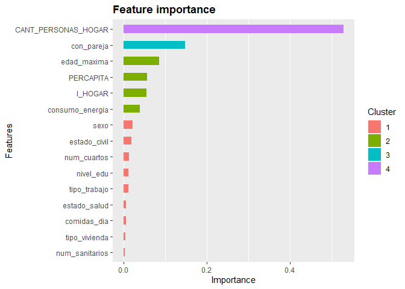

```r
P1 <- xgb.ggplot.importance(matriz_de_importancia)
print(P1)
```

# Reducción de variables en búsqueda de mejoría

```r
sub_train <- train[,c(1,8,9,10,11,15,16)]
sub_train_label  <- sub_train[,1]
sub_train_covariables <- as.matrix(sub_train[,-1])
sub_test <- test[,c(1,8,9,10,11,15,16)]
sub_test_label  <- sub_test[,1]
sub_test_covariables <- as.matrix(sub_test[,-1])
head(sub_train)
```

```
##   Hijos I_HOGAR PERCAPITA CANT_PERSONAS_HOGAR consumo_energia edad_maxima
## 1     5 3656653  365665.3                  10           62000          61
## 2     0 4200000 2100000.0                   2          189000          79
## 3     0 1365000  455000.0                   3          188800          37
## 4     0 1785722 1785721.9                   1           30000          73
## 5     1 1800000  900000.0                   2          100000          74
## 6     3 7150000 1430000.0                   5          120000          41
##   con_pareja
## 1          1
## 2          1
## 3          2
## 4          2
## 5          2
## 6          1
```

```r
sub_train_matrix <- xgb.DMatrix(data = sub_train_covariables, label = sub_train_label)
sub_test_matrix <- xgb.DMatrix(data = sub_test_covariables, label = sub_test_label)
```

```r
parametros_xgb2 <- list("objective"="multi:softprob",
                       "eval_metric"="mlogloss",
                       "num_class"=numero_de_clases,
                       eta = 0.3,
                       early_stoppin_rounds = 200,
                       nfold =5,
                       max_depth = 8)   #Se puede hacer hyperparameter tunning
modelo_xg2 <- xgb.train(params = parametros_xgb2,
                       data = sub_train_matrix, nrounds=500)
```

```
## [20:31:45] WARNING: amalgamation/../src/learner.cc:541:
## Parameters: { early_stoppin_rounds, nfold } might not be used.
##
##   This may not be accurate due to some parameters are only used in language bindings but
##   passed down to XGBoost core.  Or some parameters are not used but slip through this
##   verification. Please open an issue if you find above cases.
```

```r
# Predict para el test set
test_pred2 <- predict(modelo_xg2, newdata = sub_test_matrix)
test_prediction2 <- matrix(test_pred, nrow = numero_de_clases,
                          ncol=length(test_pred2)/numero_de_clases) %>%
  t() %>%
  data.frame() %>%
  mutate(label = sub_test_label+1,
         max_prob = max.col(., "last"))
# Matriz de confusión para el test set
confusionMatrix(factor(test_prediction2$max_prob),
                factor(test_prediction2$label),
                mode = "everything")
```

```
## Confusion Matrix and Statistics
##
##           Reference
## Prediction    1    2    3    4    5    6    7    8    9   10   11
##         1  9533  545   67    9    3    0    0    0    0    0    0
##         2  1177 5979  680  165   40    7    1    1    0    0    0
##         3   259 1019 4389  417  104   12    6    3    0    0    0
##         4    37  191  517 1518  147   46   12    2    3    1    0
##         5    13   22   74  136  401   51    7    2    2    0    0
##         6     1    9   15   34   33  122   16    5    0    0    1
##         7     1    0    2   13   15   14   27    4    0    0    0
##         8     0    0    1    5    2    1    3   14    0    1    0
##         9     0    0    0    1    1    1    2    0    5    0    0
##         10    0    0    0    0    0    0    0    0    0    0    0
##         11    0    0    0    0    0    0    0    0    0    0    0
##
## Overall Statistics
##
##                Accuracy : 0.7868
##                  95% CI : (0.7819, 0.7916)
##     No Information Rate : 0.3944
##     P-Value [Acc > NIR] : < 2.2e-16
##
##                   Kappa : 0.7051
##
##  Mcnemar's Test P-Value : NA
##
## Statistics by Class:
##
##                      Class: 1 Class: 2 Class: 3 Class: 4 Class: 5 Class: 6
## Sensitivity            0.8650   0.7700   0.7640  0.66057  0.53753 0.480315
## Specificity            0.9631   0.8974   0.9180  0.96273  0.98871 0.995883
## Pos Pred Value         0.9386   0.7427   0.7069  0.61358  0.56638 0.516949
## Neg Pred Value         0.9164   0.9102   0.9376  0.96938  0.98733 0.995237
## Precision              0.9386   0.7427   0.7069  0.61358  0.56638 0.516949
## Recall                 0.8650   0.7700   0.7640  0.66057  0.53753 0.480315
## F1                     0.9003   0.7561   0.7343  0.63621  0.55158 0.497959
## Prevalence             0.3944   0.2778   0.2056  0.08223  0.02669 0.009089
## Detection Rate         0.3411   0.2139   0.1570  0.05432  0.01435 0.004365
## Detection Prevalence   0.3634   0.2880   0.2222  0.08852  0.02533 0.008445
## Balanced Accuracy      0.9141   0.8337   0.8410  0.81165  0.76312 0.738099
##                       Class: 7  Class: 8  Class: 9 Class: 10 Class: 11
## Sensitivity          0.3648649 0.4516129 0.5000000 0.000e+00 0.000e+00
## Specificity          0.9982420 0.9995343 0.9998210 1.000e+00 1.000e+00
## Pos Pred Value       0.3552632 0.5185185 0.5000000       NaN       NaN
## Neg Pred Value       0.9983137 0.9993911 0.9998210 9.999e-01 1.000e+00
## Precision            0.3552632 0.5185185 0.5000000        NA        NA
## Recall               0.3648649 0.4516129 0.5000000 0.000e+00 0.000e+00
## F1                   0.3600000 0.4827586 0.5000000        NA        NA
## Prevalence           0.0026479 0.0011092 0.0003578 7.156e-05 3.578e-05
## Detection Rate       0.0009661 0.0005009 0.0001789 0.000e+00 0.000e+00
## Detection Prevalence 0.0027194 0.0009661 0.0003578 0.000e+00 0.000e+00
## Balanced Accuracy    0.6815534 0.7255736 0.7499105 5.000e-01 5.000e-01
```

```r
# Nombres de las variables
nombres2 <-  colnames(sub_train[,-1])
# Muestra la matriz de importancia de las variables
matriz_de_importancia2 = xgb.importance(feature_names = nombres2, model = modelo_xg2)
head(matriz_de_importancia2)
```

```
##                Feature       Gain       Cover  Frequency
## 1: CANT_PERSONAS_HOGAR 0.53620309 0.051799477 0.03078217
## 2:          con_pareja 0.17166428 0.009221184 0.02132238
## 3:         edad_maxima 0.09698118 0.101087136 0.20120454
## 4:             I_HOGAR 0.07313402 0.331115859 0.27040566
## 5:           PERCAPITA 0.06880739 0.348660484 0.26414789
## 6:     consumo_energia 0.05321003 0.158115861 0.21213736
```

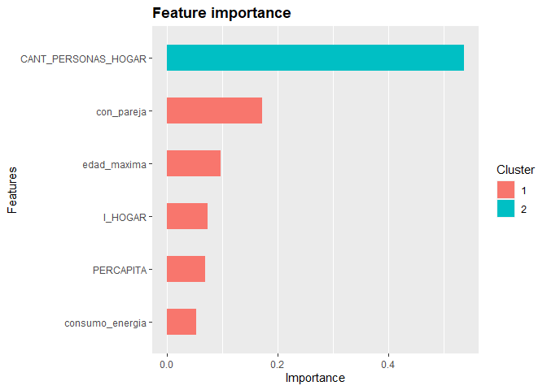

```r
P2 <- xgb.ggplot.importance(matriz_de_importancia2)
print(P2)
```